# DaVinci Bi-modal integration: Mouse Postnatal Brain (spatial ARP-seq, RNA + ATAC)

# Overview

This notebook runs a **bi-modal integration** workflow for spatial ARP-seq data using **DaVinci**. The analysis proceeds in three stages:

1. **Horizontal integration within RNA** across sections (cross-section integration)
2. **Horizontal integration within ATAC** across sections
3. **Vertical (cross-modality) integration** between RNA and ATAC, followed by clustering, optional spatial refinement, and visualization

## Setup

Load DaVinci and set the working directory.

```r
library(DaVinci)
library(ggpubr)

setwd("~/For_Tutorial/ARP-seq/")
```

# Part I — Horizontal integration across sections (RNA)

## Load RNA section files and preprocess

We read each RNA section from `data.dir/RNA/`. Each RDS file is expected to contain: - `mat`: feature-by-spot raw counts matrix - `coor`: spot-by-(x,y) coordinates

We preprocess each section with `preprocess(..., type="rna", graph.opt="Tri.mesh")` and collect: - `Y.list`: processed data matrix per section - `L.list`: spatial graph/Laplacian per section - `coor.list`: aligned coordinates per section

```r
data.dir <- "~/For_Tutorial/ARP-seq/data/"

dataset.opts <- list.files(paste0(data.dir, "RNA/"))
dataset.opts <- gsub(".RDS", "", dataset.opts)

Y.list <- list()
L.list <- list()
coor.list <- list()

for (ii in seq_along(dataset.opts)) {
  input <- readRDS(paste0(data.dir, "RNA/", dataset.opts[ii], ".RDS"))

  fin <- preprocess(
    input$mat,
    input$coor,
    type = "rna",
    graph.opt = "Tri.mesh",
    frac.thr = 0.95
  )

  Y.list[[ii]] <- fin$mat
  L.list[[ii]] <- fin$L
  coor.list[[ii]] <- fin$coor
}

names(coor.list) <- dataset.opts
```

## Run RNA horizontal integration

`Horizontal.Integration.Assemble()` searches over a candidate list of latent dimensions (`k.arg.list`) and integrates robust latent variables across sections.

```r
RNA.res <- Horizontal.Integration.Assemble(
  dataset.opts = dataset.opts,
  Y.list  = Y.list,
  L.list  = L.list,
  coor.list = coor.list,
  k.arg.list = c(4, 6, 8, 10, 11, 12, 13, 15, 16, 18, 20, 22, 24)
)
```

# Part II — Horizontal integration across sections (ATAC)

## Load ATAC section files and preprocess

We repeat the same steps for ATAC. In the original script, `type="rna"` is used in `preprocess()` for ATAC matrices as well. If you have an ATAC-specific preprocessing pathway (e.g., LSI), you may want to switch to `type="atac"` and add LSI parameters. Here we keep the original behavior for fidelity.

```r
dataset.opts <- list.files(paste0(data.dir, "ATAC/"))
dataset.opts <- gsub(".RDS", "", dataset.opts)

Y.list <- list()
L.list <- list()
coor.list <- list()

for (ii in seq_along(dataset.opts)) {
  input <- readRDS(paste0(data.dir, "ATAC/", dataset.opts[ii], ".RDS"))

  fin <- preprocess(
    input$mat,
    input$coor,
    type = "rna",
    graph.opt = "Tri.mesh",
    frac.thr = 0.95
  )

  Y.list[[ii]] <- fin$mat
  L.list[[ii]] <- fin$L
  coor.list[[ii]] <- fin$coor
}

names(coor.list) <- dataset.opts
```

## Run ATAC horizontal integration

```r
ATAC.res <- Horizontal.Integration.Assemble(
  dataset.opts = dataset.opts,
  Y.list  = Y.list,
  L.list  = L.list,
  coor.list = coor.list,
  k.arg.list = c(4, 6, 8, 10, 11, 12, 13, 15, 16, 18, 20, 22, 24)
)
```

# Part III — Vertical integration (RNA + ATAC), clustering, refinement, visualization

## Align shared pixels between modalities

We take the integrated matrices from RNA and ATAC, assign unique row identifiers of the form `<slice>@<pixel>`, and then restrict both matrices to their intersection (pixels present in both modalities).

```r
mat.RNA <- RNA.res$mat
mat.ATAC <- ATAC.res$mat

rownames(mat.RNA) <- paste0(RNA.res$mat.slice.id, "@", rownames(mat.RNA))
rownames(mat.ATAC) <- paste0(ATAC.res$mat.slice.id, "@", rownames(mat.ATAC))

sids.intersect <- intersect(rownames(mat.RNA), rownames(mat.ATAC))
mat.RNA <- mat.RNA[sids.intersect, ]
mat.ATAC <- mat.ATAC[sids.intersect, ]

sids <- rownames(mat.RNA)
mat.slice.id <- unlist(lapply(strsplit(sids, "@"), function(x) x[1]))
sids.pixel <- unlist(lapply(strsplit(sids, "@"), function(x) {x[2]}))
```

## Run bi-modal integration and cluster

`BiModalIntegration()` builds a cross-modality neighbor graph, which we cluster using `leiden_adaptive()`. The resulting `partition` is a cluster label per pixel.

```r
integration.res <- BiModalIntegration(
  modal.1 = mat.RNA,
  modal.2 = mat.ATAC,
  n_neighbors = 40,
  n_neighbors_large = 40,
  L2norm = "column"
)
```

```
## [1] "No adjustment with reference UMI."
```

```r
partition <- leiden_adaptive(
  integration.res$snn.mat,
  num.of.cluster = 18,
  resolution.start = 0.4,
  adaptive.size = 2,
  method = "louvain"
)
```

```
## 1.6 0.8 1.6
```

```
## 1.2 0.8 1.6
```

```
## 1 0.8 1.2
```

```
## 1.1 1 1.2
```

```r
partition <- as.character(partition)
names(partition) <- sids.pixel
```

## Local smoothing / spatial refinement

We optionally refine cluster labels within each section using `DaVinci:::refinement()` with a KNN neighborhood.

**Important:** the coordinates used here must be aligned to the *same pixel IDs* used in `names(partition)`. In this script, `names(partition)` are the *pixel IDs without the slice prefix* (e.g., the part after `"@"`). This matches the original code and assumes `rownames(coor.list.<...>[[ii]])` are also pixel IDs (without slice prefixes).

```r
partition.smooth <- partition


for (ii in seq_along(dataset.opts)) {
  subpart.index <- which(mat.slice.id == dataset.opts[ii])

  p.part <- partition[subpart.index]

  p.part <- DaVinci:::refinement(
    p.part,
    as.matrix(coor.list[[ii]])[names(p.part), ],
    neighbor.option = "KNN",
    neighbor.arg = 8,
    tasks = "discrete"
  )

  partition.smooth[subpart.index] <- p.part
}
```

## Visualize clusters across sections

We define per-section orientation settings (named by section IDs) and then visualize cluster assignments with `scatter.DiscretePlot.list()`.

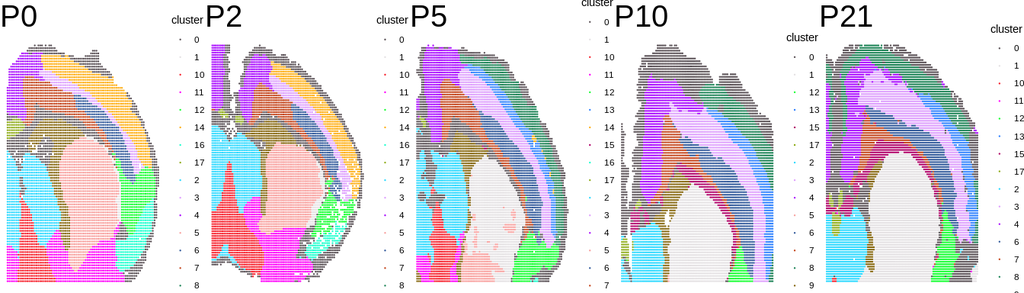

```r
orientation.opts <- c("yx", "yx", "y-x", "y-x", "-x-y")
names(orientation.opts) <- c("P0", "P2", "P5", "P10", "P21")

par.to_plot <- partition.smooth

plot.list <- scatter.DiscretePlot.list(
  par.to_plot,
  coor.list,
  mat.slice.id,
  dataset.opts,
  pt.size = 0.2,
  title.size = 30,
  orientation = orientation.opts,
  ratio = NULL,
  return.obj = TRUE
)

ggarrange(
  plotlist = plot.list[match(c("P0", "P2", "P5", "P10", "P21"), dataset.opts)],
  nrow = 1
)
```

# Part IV — Subclustering a selected cluster

Sometimes a cluster contains substructure. Here we subcluster the pixels assigned to cluster `"14"` using the same graph, restricted to those pixels.

```r
par.to_plot <- partition.smooth
subcluster.index <- which(par.to_plot == "14")

ptm <- proc.time()
partition.sub <- leiden_adaptive(
  integration.res$snn.mat[subcluster.index, subcluster.index],
  num.of.cluster = 2,
  resolution.start = 0.4,
  adaptive.size = 2,
  method = "louvain"
)
print(proc.time() - ptm)
```

```
##    user  system elapsed
##   0.311   0.000   0.311
```

```r
par.update <- par.to_plot
par.update[subcluster.index] <- paste0("N", partition.sub)

# Manual relabeling based on domain knowledge:
# N0 is more dorsal
par.update[par.update == "N0"] <- "8"
par.update[par.update == "N1"] <- "13"

# Renumber to keep labels coherent (as in original script)
par.update[par.update == "15"] <- "14"
par.update[par.update == "16"] <- "15"
par.update[par.update == "17"] <- "16"
```

## Visualize updated clusters (white-on-black background)

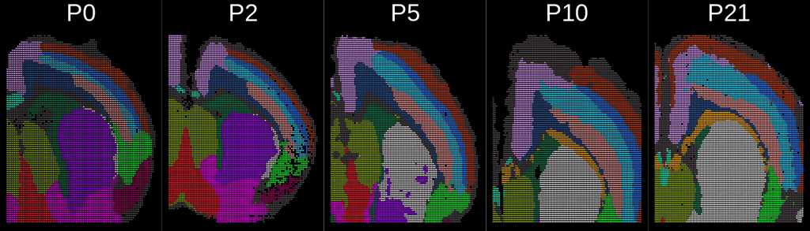

```r
plot.list <- scatter.DiscretePlot.list(
  par.update,
  coor.list,
  mat.slice.id,
  dataset.opts,
  pt.size = 0.2,
  title.size = 30,
  orientation = orientation.opts,
  ratio = NULL,
  return.obj = TRUE
)

for (ii in seq_along(plot.list)) {
  plot.list[[ii]] <- plot.list[[ii]] +
    theme(
      plot.title = element_text(color = "white", hjust = 0.5),
      plot.background = element_rect(fill = "black"),
      legend.position = "none"
    )
}

ggarrange(
  plotlist = plot.list[match(c("P0", "P2", "P5", "P10", "P21"), dataset.opts)],
  nrow = 1
)
```